# Day 16 - LSTM - 长短期记忆网络

> 目标: 理解 LSTM 如何用三个门解决 RNN 的梯度消失问题

> 核心: 细胞状态 C_t (信息高速公路) + 三个门 (遗忘/输入/输出)

## RNN vs LSTM

```
RNN:   h_t = tanh(W_xh * x_t + W_hh * h_{t-1})
       只有一个隐藏状态, 梯度连乘 -> 消失

LSTM:  C_t = f_t * C_{t-1} + i_t * C~_t    (细胞状态, 加法!)
       h_t = o_t * tanh(C_t)               (隐藏状态)
       加法传递梯度 -> 梯度不会消失!

RNN 的梯度路径:   连乘 (W_hh^T)^{T-1}  → 指数衰减
LSTM 的梯度路径:  加法 C_t = f_t * C_{t-1} + ...  → 梯度直通!
```

```
========================================
Day 16 - LSTM
========================================
```

## 1. LSTM 的三个门

> LSTM 的关键创新: 细胞状态 C_t (Cell State) —— 一条贯穿所有时间步的信息高速公路

### 遗忘门 (Forget Gate) - 决定扔掉什么

```
f_t = sigmoid(W_f * [h_{t-1}, x_t] + b_f)
输出 0~1, 乘到 C_{t-1} 上
  1 = 完全保留这段记忆
  0 = 完全丢弃这段记忆
```

### 输入门 (Input Gate) - 决定写入什么

```
i_t = sigmoid(W_i * [h_{t-1}, x_t] + b_i)    ← 写入哪些位置
C~_t = tanh(W_C * [h_{t-1}, x_t] + b_C)      ← 要写入的新信息
```

### 输出门 (Output Gate) - 决定输出什么

```
o_t = sigmoid(W_o * [h_{t-1}, x_t] + b_o)    ← 输出哪些位置
h_t = o_t * tanh(C_t)                          ← 输出门调控隐藏状态
```

### 完整流程

```
   C_{t-1}                 C_t
      |                     ^
      |   遗忘  +   输入    |
      |    f_t  *  C_{t-1}  +  i_t * C~_t
      v                     |
  [x_t, h_{t-1}] -> 三个门 -> o_t -> h_t

只有加法! C_t = f_t * C_{t-1} + i_t * C~_t
加法路径的梯度 = 1, 不会消失!
```

```
输入形状: (5, 4)
隐藏状态形状: (5, 8)
最后时间步 h[:8]: [-0.0539 -0.0022 -0.0175 -0.0531 -0.0188  0.0157  0.0154  0.0373]
```

## 2. 梯度消失对比实验: RNN vs LSTM

> RNN 的梯度经过连乘, LSTM 的梯度经过加法 + 遗忘门

> 实验: 给两个网络相同的输入, 观察 x1 对后面 h_t 的影响

```
RNN:   dh_t/dh_{t-1} = W_hh^T * tanh'(h_{t-1})      ← 连乘, 必然消失
LSTM:  dC_t/dC_{t-1} = f_t                            ← 遗忘门控制的加法!
       如果 f_t ≈ 1, 梯度几乎无损传递
```

[output not shown]

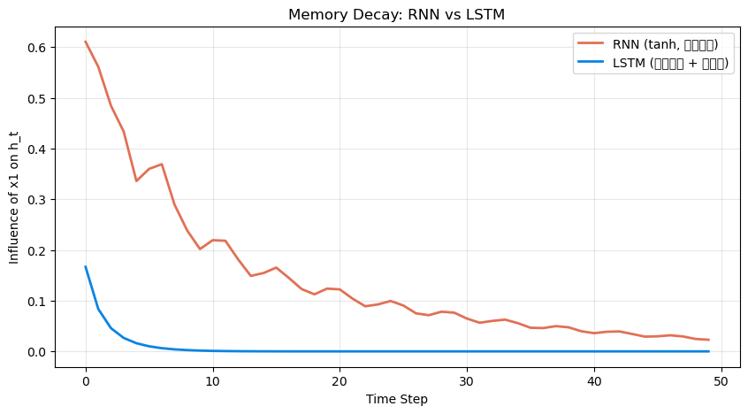

[output not shown]

## 3. PyTorch nn.LSTM 使用

> 用法跟 nn.RNN 完全一致, 但多返回一个细胞状态 C

```
nn.LSTM(input_size, hidden_size, num_layers, batch_first, dropout, bidirectional)

输出:
  output: (batch, seq_len, hidden_size * num_directions)
  (hn, cn): (num_layers * num_directions, batch, hidden_size)
            ↑ 隐藏状态          ↑ 细胞状态
```

```
input:  (4, 7, 10)
output: (4, 7, 20)
hn:     (2, 4, 20)  ← 隐藏状态
cn:     (2, 4, 20)  ← 细胞状态
output[:,-1] == hn[-1]: True

参数数量对比:
  RNN:  1,480
  LSTM: 5,920
```

## 4. 实战: LSTM 正弦波预测 (vs RNN)

> 同样的任务 (前 10 步 -> 下一步), 对比 LSTM 和 RNN 的效果

```
训练集: (792, 10, 1)
测试集: (198, 10, 1)
```

```
LSTM 参数量: 4,513
RNN  参数量: 1,153
```

```
训练 LSTM...
LSTM 测试 MSE: 0.000001

训练 RNN...
RNN  测试 MSE: 0.000001
```

[figure not shown]

## 5. 实战: LSTM 文本生成 (vs RNN)

> 同样的字符预测任务, 对比 LSTM 和 RNN 的生成质量

```
字符集: [' ', 'd', 'e', 'h', 'l', 'o', 'r', 'w']
样本数: 7
LSTM Char 参数量: 1,864
RNN  Char 参数量: 616
```

```
训练 Char-LSTM...
  Epoch  20 | Loss = 0.0667
  Epoch  40 | Loss = 0.0662
  Epoch  60 | Loss = 0.0661
  Epoch  80 | Loss = 0.0661
  Epoch 100 | Loss = 0.0661

训练 Char-RNN...
  Epoch  20 | Loss = 0.0667
  Epoch  40 | Loss = 0.0660
  Epoch  60 | Loss = 0.0662
  Epoch  80 | Loss = 0.0660
  Epoch 100 | Loss = 0.0660
```

```
生成结果对比:
  LSTM: "hell" -> "hello world world w"
  RNN:  "hell" -> "hello world world w"

  LSTM: " wor" -> " world world w"
  RNN:  " wor" -> " world world w"
```

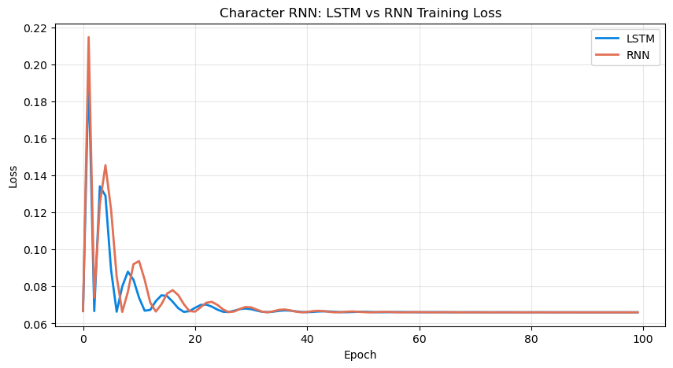

# Day 16 完成!

## 今天学到了什么

[output not shown]

## LSTM 梯度分析

```
RNN:   dh_t/dh_{t-1} = W_hh^T * tanh'(h_{t-1})
       连乘 T 次 -> 指数级消失

LSTM:  dC_t/dC_{t-1} = f_t
       如果 f_t ≈ 1:  梯度无损! 记忆可以传 1000 步
       如果 f_t ≈ 0:  丢弃旧记忆, 重置
       网络可以学习 f_t 的值 -> 自主决定什么时候遗忘!
```

## 作业 (代码定位)

### [作业 1] 增大 LSTM 容量

**位置:** cell-10, `LSTMPredictor` 类, 第 11 行: `model_lstm = LSTMPredictor(hidden_size=32)`

**问题:** 把 `hidden_size=32` 改成 `64`, LSTM 的效果会更好吗? 训练时间变长多少?

### [作业 2] 参数计算

**位置:** cell-14, 末尾两行: `sum(p.numel() for p in model_lstm_char.parameters())`

**问题:** LSTM 的参数量是 RNN 的几倍? 为什么?

- 提示 1: 先跑 cell-7 看参数数量对比
- 提示 2: LSTM 一个时间步算了几组线性变换?

### [作业 3] 延长训练

**位置:** cell-15, 第 6 行: `def train_char_model(model, x, y, epochs=100, ...)`

**问题:** 把 `epochs=100` 改成 `epochs=200`, LSTM 能否学会完整的 "hello world"序列?

- 修改后重新跑 cell-15 + cell-16 即可看到结果
- 观察 RNN 的 loss 是否停滞, LSTM 是否继续下降

### [作业 4] 双向 LSTM

**位置:** cell-14, 第 25 行: `self.rnn = rnn_cell(embed_size, hidden_size, batch_first=True)`

**问题:** 加上 `bidirectional=True`, 参数量怎么变化? 生成效果变好还是变差?

- 注意: 加上双向后, fc 层的输入维度也要翻倍 (`hidden_size * 2`)
- 修改位置在 `BaseCharModel.__init__` 的 self.fc 行

### [作业 5] 预习

预习 Day 17: GRU — 把 LSTM 的三个门简化成两个 (更新门 + 重置门), 参数更少效果相近